# Data Visualization, Modeling, and R Programming

Prepared by Graham Landry for Brierley+Partner’s Consumer Insights Team

April 7th, 2017

# This Week’s Training Schedule

The trainings this week will introduce you to the R language as well as demonstrate common tasks during data analysis. We will begin today with an overview of the R language before moving on to importing/writing files, data manipulation, data visualization, modeling, and an introduction to R programming.

Whether the information we cover today is brand new or review, it’s a good place to start as it forms the requisite knowledge for the concepts presented on Day 2 and Day 3- not to mention anything else you might want to explore with your knew skills in R.

**The ultimate goal of these trainings is to provide you with a solid foundation upon which you can continue to explore the language and further develop your skillset.**

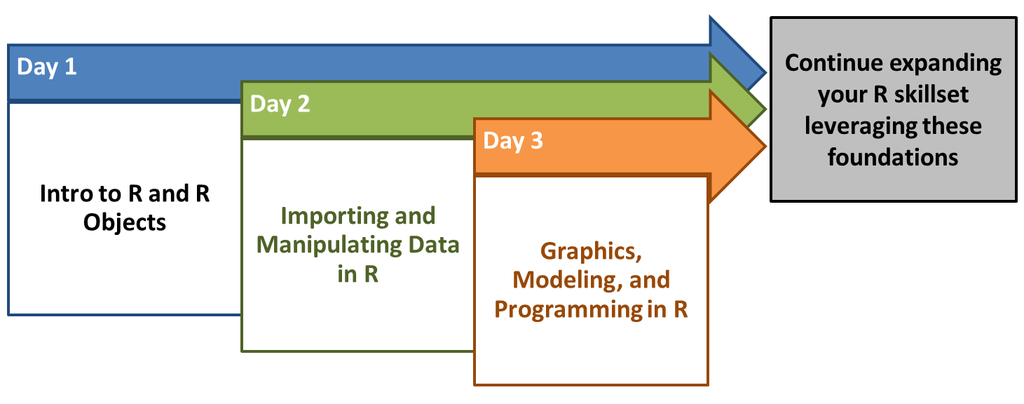

# Topics for Today’s Training

- Introduction to ggplot2
- The Grammar of Graphics
- Visualizing Data with ggplot2
- Introduction to caret
- Modeling with caret
- Control Flow
- Writing Your Own Functions
- Additional Resources
- Week in Review / Q&A

# Try it!: Load Packages and Read Data

1. Install/Load the following packages: readr, dplyr, ggplot2, caret, rpart.plot

```r
packages <- c("readr", "dplyr", "ggplot2", "caret", "rpart.plot")

for (p in packages) {
    if (!require(p, character.only = TRUE)) {
        install.packages(p)
        library(p, character.only = TRUE)
    } else {
        library(p, character.only = TRUE)
    }
}
```

2. Read into R the “banksmp.csv” file

```r
banksmp <- read_csv("C:\\Users\\glandry\\Desktop\\Projects\\R-Training\\assets\\data\\banksmp.csv", col_types = list(
    age = col_integer(),
    age_group = col_factor(c("Millennial", "GenX", "Boomer")),
    job = col_factor(c("admin.", "blue-collar", "entrepreneur", "housemaid","management", "retired","self-employed",
                       "services", "student", "technician", "unemployed", "unknown")),
    marital = col_factor(c("divorced", "married", "single")),
    education = col_factor(c("primary", "secondary", "tertiary", "unknown")),
    balance = col_integer(),
    housing = col_factor(c("no", "yes")),
    loan = col_factor(c("no", "yes")),
    contact = col_factor(c("cellular", "telephone", "unknown")),
    duration = col_integer(),
    campaign = col_integer(),
    pdays = col_integer(),
    previous = col_integer(),
    poutcome = col_factor(c("failure", "other", "success", "unknown")),
    td_enroll = col_factor(c("no", "yes"))
))
```

# Visualizing Data with ggplot2

We’ll be exploring another member of the **tidyverse** package family called **ggplot2** which uses a *grammar of graphics* in combination with other graphics packages to make visualizing data in R effortless.

This package has been widely adopted because of how easy it is to build attractive plots, especially once the structure is understood. It also has a rich set of features that are not as easy as (or available in) *base*:

- Easily create *plot objects* that can be saved and editted later
- Merge disparate datasets into the same plot
- Annotate and label plots easily, with several options for customization
- Add trend lines to a graph without first having to build a model
- Write plot images to your machine for use in other platforms
- Combine ggplot’s grammar of graphics in the same code chunk as readr, stringr, dplyr, etc. operations
- And more! See the [ggplot2 online documentation](http://docs.ggplot2.org/current/index.html)

**Note** as a member of the **tidyverse** family it can use the piping operator **%>%** to easily chain together lines of code.

# The Grammar of Graphics

The *grammar of graphics* is based upon a book of the same name by Leland Wilkinson, which describes an approach to data visualization through *layering* components together. The **ggplot2** package is designed based upon this approach. The *layers* used to build plots include:

- **Data**: the information you wish to visualize, along with a set of **aesthetic** mappings which describe how variables *map* to visual attributes (i.e. size, color, etc.)
- **Layers**: what is actually displayed on the plot. This component is comprised of both **geoms** and **stats**- the first is the shape used for a plot, and the latter is a statistical summary
- **Scales**: define how data values are mapped into aesthetics (e.g. which colors to assign to each level of categorical variable). Scales also control the legends and axis on a plot
- **Coords**: controls how coordinates are mapped to a plane, as well as provides gridlines and axes
- **Facets**: a description of how to break up the data into subsets and display them as small multiples
- **Themes**: controls the general appearance of the visualization, from background color to font size. You can used either predefined themes, or create your own customized theme

**Note** it is worthwhile to spend some time reading *ggplot2* by Hadley Wickham as it goes into great detail on each of these layers and full demonstrates the level of customization in each.

# The ggplot2 Recipe

Using the *grammar of graphics* to build a plot is very convenient, and especially after some practice. The basic recipe for creating a plot with **ggplot2** follows the format below. While these are the most common, of course there are more/ different types of *layers* you can add to your plots (which is why you should read the documentation!)

```r
# create the plot base, define your dataset and global aesthetic options
ggplot(...) +
    # add a geom layer to define how the data is represented visually
    geom_XXX(...) +
    # add a title to the plot
    ggtitle(...) +
    # change the theme to customize the appearance of your plot
    theme(...)
```

Using the **ggsave()** function, you can save a plot image to your machine. It takes two arguments, the name of a plot object and the file name you wish to write. If you don’t pass the function an object, it will default to saving the last plot in memory.

```r
# assuming you have a plot object named "plt", you could save it explicity as a .PNG by
ggsave(plt, "filename.png")

# else, if you wanted to save the last plot in memory you could do the following
ggsave("filename.png")
```

# Visualizing the Grammar of Graphics

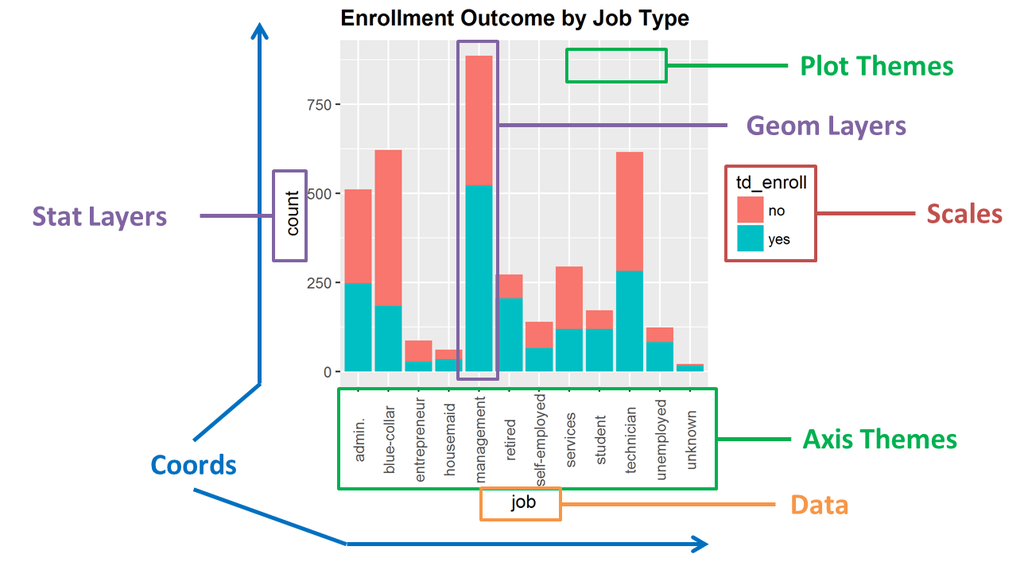

*Fig 3.1: Components of the Grammar of Graphics*

# Common Geoms

There are many different options to choose from for the **geom** layer, and some of the most common are:

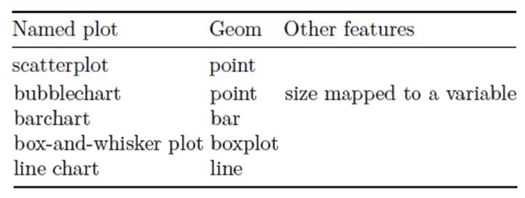

*Fig 3.1: Common ggplot2 Geoms*

*Source: ggplot2 by Hadley Whickham (pg. 81)*

Let’s take a brief detour to the *ggplot2* website and go through the [full list of geom objects](http://docs.ggplot2.org/current/).

# Common Aesthetics

The most commonly used aesthetics are:

- **x**: the data column to present on the x-axis
- **y**: the data column to present on the y-axis
- **Color**: the color of the geom (i.e. line, point, bar, etc.)
- **Fill**: the color of the fill for a geom where it applies (i.e. point, density)
- **Size**: the size of the geom
- **Shape**: the specific style of geom (i.e. filled point vs. hollow point)

To put these options into context, let’s take another detour and look at some [aesthetic specifications](http://docs.ggplot2.org/current/vignettes/ggplot2-specs.html).

# Visualizing Data: bar chart

A bar chart can be created with the **geom_bar()** geom. If you have continuous data, you can create a histogram with the **geom_histogram()** geom (which uses a default of 30 bins).

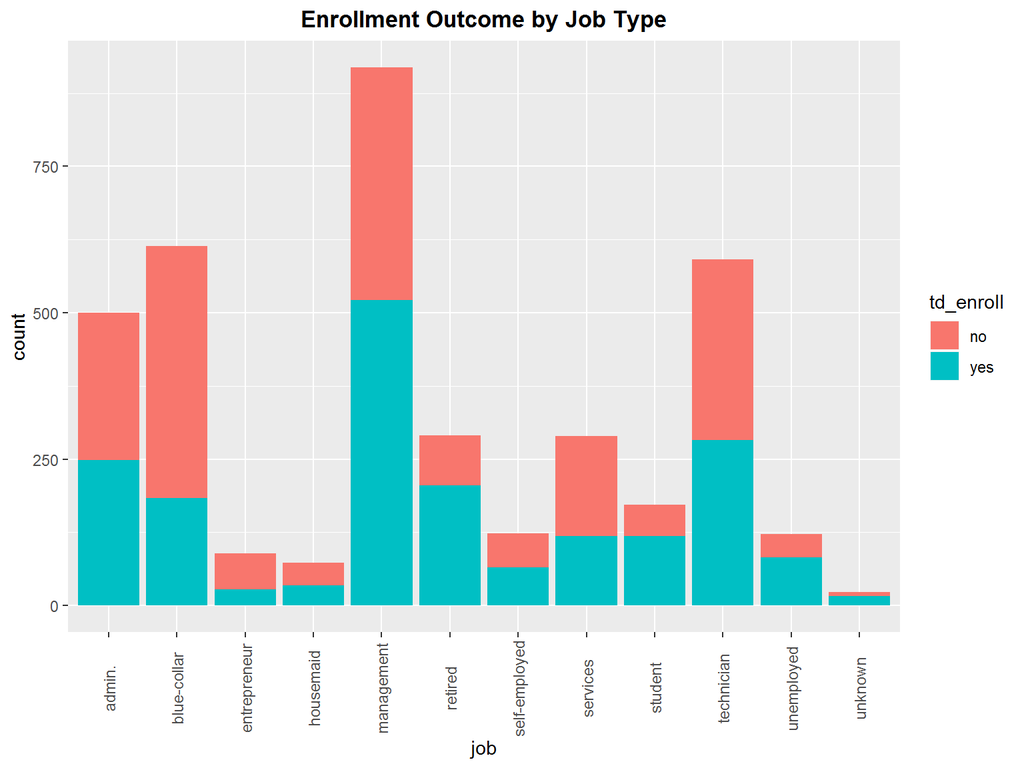

```r
banksmp %>%
    ggplot(aes(x = job, fill = td_enroll)) +
    geom_bar() +
    ggtitle("Enrollment Outcome by Job Type") +
    theme(axis.text.x = element_text(angle = 90, vjust = 0.5),
          plot.title = element_text(face = "bold", hjust = 0.5))
```

# Try it!: Creating a bar-chart

Which of these code chunks would result in the plot below?

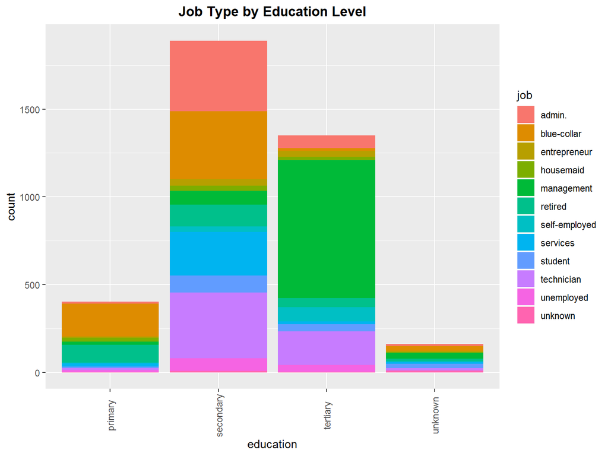

# Try it!: Creating a bar-chart (MC)

```r
### Option A
banksmp %>%
    ggplot(aes(x = education, fill = td_enroll)) +
    geom_bar() +
    ggtitle("Job Type by Education Level") +
    theme(axis.text.x = element_text(angle = 90, vjust = 0.5))

### Option B
banksmp %>%
    ggplot(aes(x = age_group)) +
    geom_point() +
    ggtitle("Distribution of Records by Age Group") +
    theme(plot.title = element_text(face = "bold"))

### Option C
banksmp %>%
    ggplot(aes(x = education, fill = job)) +
    geom_bar() +
    ggtitle("Job Type by Education Level") +
    theme(axis.text.x = element_text(angle = 90, vjust = 0.5),
          plot.title = element_text(face = "bold", hjust = 0.5))
```

# Visualizing Data: Density Polygon

Another way to visualize a continuous distribution is with the **geom_density()** geom. This layer has a *smoothing* parameter you can adjust to make the curve more or less smooth.

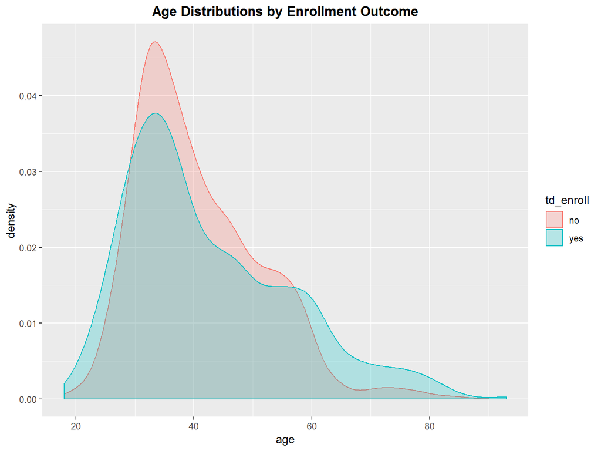

```r
banksmp %>%
    ggplot(aes(x = age, fill = td_enroll, color = td_enroll)) +
    geom_density(alpha = 0.25) +
    ggtitle("Age Distributions by Enrollment Outcome") +
    theme(plot.title = element_text(face = "bold", hjust = 0.5))
```